[output not shown]

# Introduction

At the first day of class there are 35 students in Math Statistics class and professor Brownlow always proposes this bet to his students “I will wager $2 to your bet of $1 that at least two people in today’s class have the same birthday. He tells me he has made that bet 1137 times so far. Where do you think his profits are? Discuss this in a markdown document

# Profit Estimate

First we create the year data and a vector to contain.

```r
Bdays = 1:365
Bsamples = vector("numeric")
TotalDollars= 0
saveDollars=vector('numeric')
```

Run this simulation 1137 times

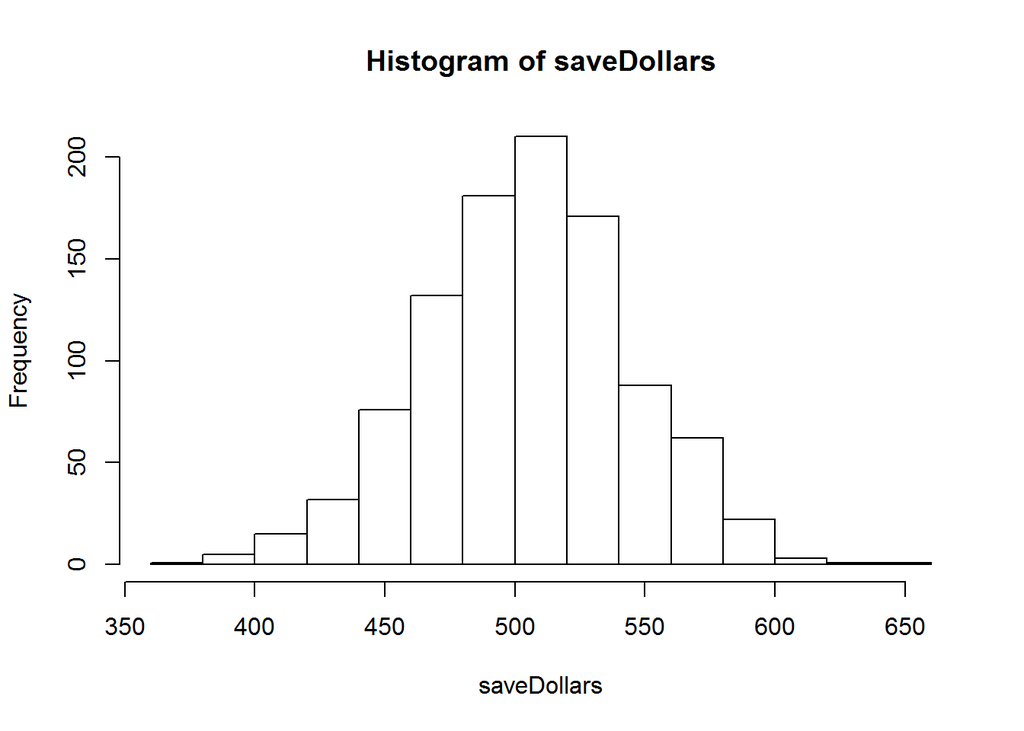

```r
for(loop in 1:1000){

  TotalDollars= 0
  classSize= 35
  for(i in 1:1137) {
    Bsamples = sample(Bdays,35, replace= TRUE)
   if (length(unique(Bsamples)) == classSize) {
     TotalDollars = TotalDollars -2
   } else{
     TotalDollars = TotalDollars +1
   }
  }

  saveDollars[loop] = TotalDollars
  }
  hist(saveDollars)
```

```r
  var(saveDollars)
```

```
## [1] 1569.617
```

```r
  print(paste("average return =",mean(saveDollars)))
```

```
## [1] "average return = 505.05"
```

The mean for the whole test is 505. What was actually earned is 477. Using resampling I found the average amount of dollars made per test was around 504.

# Confidence interval of Brownlows earning

```r
varSorted = sort(saveDollars)
LCL = varSorted[25]
UCL = varSorted[975]
print(paste("UCL = ",UCL,"LCL = ",LCL))
```

```
## [1] "UCL =  582 LCL =  423"
```

We assign values for mean, standard deviation, and sample size to rstudio in a formula. We use our data to creat a code to provide us with a confidence interval.

```r
stdevDollars = sd(saveDollars)
meanDollars = mean(saveDollars)
CI = c(meanDollars-2*stdevDollars, meanDollars+2*stdevDollars)

print(CI)
```

```
## [1] 425.8132 584.2868
```

# Discussion and Conclusion

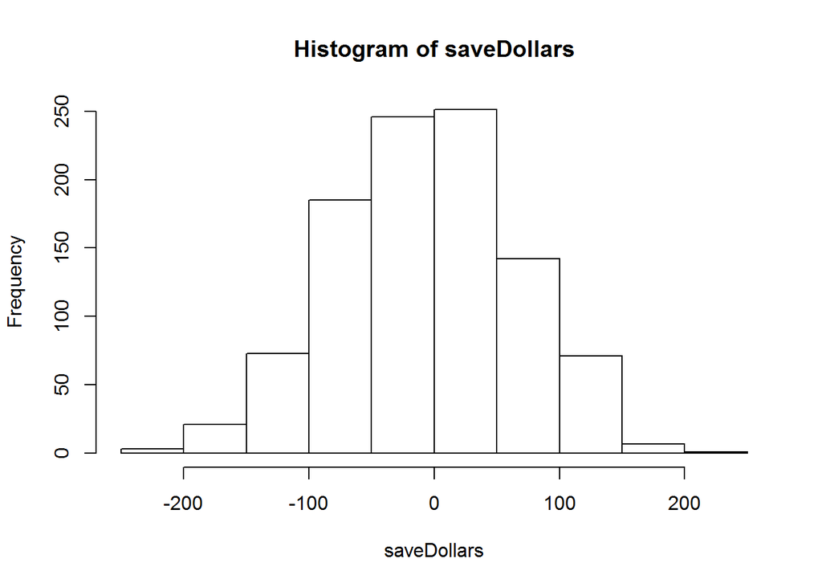

```r
TotalDollars= 0
saveDollars=vector('numeric')
for(loop in 1:1000){

  TotalDollars= 0
  ClassSize= 35
  for(i in 1:1137) {
    Bsamples = sample(Bdays,classSize, replace= TRUE)
    if (length(unique(Bsamples)) == classSize) {
      TotalDollars = TotalDollars -4.4
    } else{
      TotalDollars = TotalDollars +1
    }
  }
  saveDollars[loop] = TotalDollars +1
  }
  hist(saveDollars)
```

```r
  var(saveDollars)
```

```
## [1] 5082.681
```

```r
  print(paste("average return =",mean(saveDollars)))
```

```
## [1] "average return = -5.0828000000001"
```

We used the same set up as before and kept the original class size number. I tried payouts of -3, -10, and I found evntually that a payoff of -4.4 was the ‘fair’ amount. For every 4.4 dollars that he bets to every 1 dollar he breaks even.

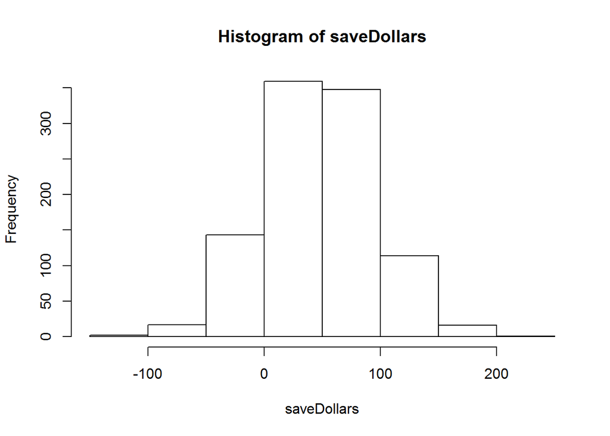

```r
TotalDollars= 0
saveDollars=vector('numeric')
for(loop in 1:1000){

  TotalDollars= 0
  ClassSize= 29
  for(i in 1:1137) {
    Bsamples = sample(Bdays,ClassSize, replace= TRUE)
    if (length(unique(Bsamples)) == ClassSize) {
      TotalDollars = TotalDollars -2
    } else{
      TotalDollars = TotalDollars +1
    }
  }
  saveDollars[loop] = TotalDollars
  }
  hist(saveDollars)
```

```r
  var(saveDollars)
```

```
## [1] 2267.145
```

```r
  print(paste("average return =",mean(saveDollars)))
```

```
## [1] "average return = 47.517"
```